# Part 2. 데이터 전처리

### 2. 데이터 변환

#### 1. 파생 변수

> df$변수명 : 새 변수 생성

> transform(df, 변수명=함수) : 새 변수 or 더미 변수 생성

※ 더미 변수 생성 시, 기준이 되는 범주를 제외한 (n-1)개의 더미 변수 생성

```r
data(iris)
dt <- iris

# df$
dt$Sum.Length <- dt$Sepal.Length+dt$Petal.Length

# transform
dt_new <- transform(dt,
                    Species_setosa = ifelse(Species=='setosa',1,0),
                    Species_versicolor = ifelse(Species=='versicolor',1,0))
head(dt_new)
```

```
##   Sepal.Length Sepal.Width Petal.Length Petal.Width Species Sum.Length
## 1          5.1         3.5          1.4         0.2  setosa        6.5
## 2          4.9         3.0          1.4         0.2  setosa        6.3
## 3          4.7         3.2          1.3         0.2  setosa        6.0
## 4          4.6         3.1          1.5         0.2  setosa        6.1
## 5          5.0         3.6          1.4         0.2  setosa        6.4
## 6          5.4         3.9          1.7         0.4  setosa        7.1
##   Species_setosa Species_versicolor
## 1              1                  0
## 2              1                  0
## 3              1                  0
## 4              1                  0
## 5              1                  0
## 6              1                  0
```

#### 2. 변수 축소

- 주성분 분석

> princomp(data, cor=FALSE, scores=TRUE) : 주성분분석
> - cor : TRUE=상관행렬로(측정단위 표준화) /FALSE=공분산행렬로(측정단위 반영)
> - scores : 각 주성분의 점수를 계산해야 하는지 => 주성분들의 선형식을 통해 각 행별 좌표 계산

> plot(prin_df, type=‘l’) : scree plot

> biplot(prin_df) : 제1주성분과 제2주성분으로 이루어진 좌표평면상에 원데이터 행들의 주성분점수를 산점도형태로, 주성분계수를 화살표로

```r
data(USArrests)
US_prin <- princomp(USArrests, cor = TRUE)

head(US_prin$loadings) # 주성분 계수(주성분에 기여하는 가중치)
```

```
##             Comp.1     Comp.2     Comp.3      Comp.4
## Murder   0.5358995  0.4181809  0.3412327  0.64922780
## Assault  0.5831836  0.1879856  0.2681484 -0.74340748
## UrbanPop 0.2781909 -0.8728062  0.3780158  0.13387773
## Rape     0.5434321 -0.1673186 -0.8177779  0.08902432
```

```r
head(US_prin$scores) # 주성분들의 선형식을 통해 계산된 각 행별 좌표
```

```
##                Comp.1     Comp.2      Comp.3       Comp.4
## Alabama     0.9855659  1.1333924  0.44426879  0.156267145
## Alaska      1.9501378  1.0732133 -2.04000333 -0.438583440
## Arizona     1.7631635 -0.7459568 -0.05478082 -0.834652924
## Arkansas   -0.1414203  1.1197968 -0.11457369 -0.182810896
## California  2.5239801 -1.5429340 -0.59855680 -0.341996478
## Colorado    1.5145629 -0.9875551 -1.09500699  0.001464887
```

```r
summary(US_prin) # 누적 기여율이 85%이상인 주성분 개수까지 선택
```

```
## Importance of components:
##                           Comp.1    Comp.2    Comp.3     Comp.4
## Standard deviation     1.5748783 0.9948694 0.5971291 0.41644938
## Proportion of Variance 0.6200604 0.2474413 0.0891408 0.04335752
## Cumulative Proportion  0.6200604 0.8675017 0.9566425 1.00000000
```

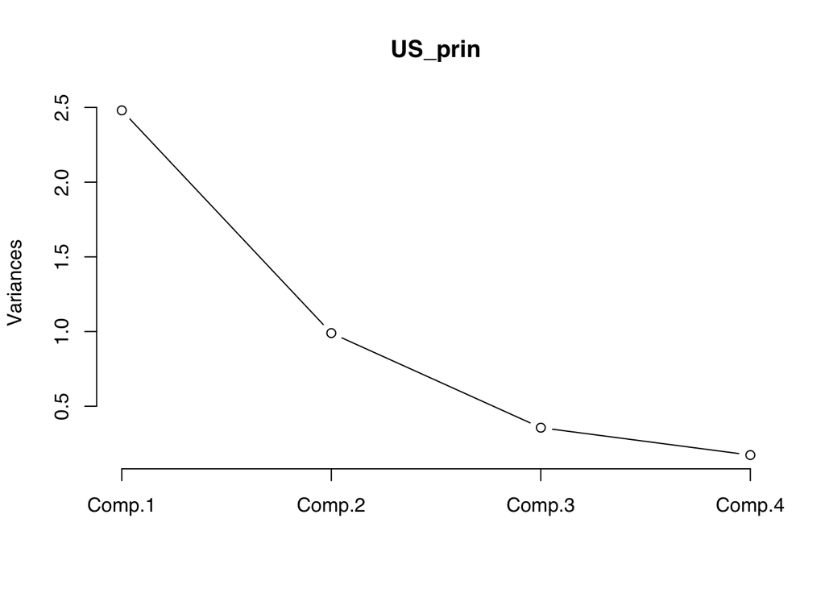

```r
plot(US_prin, type='l') # 기울기가 급격하기 줄어드는 (n-1)번째 주성분까지 선택
```

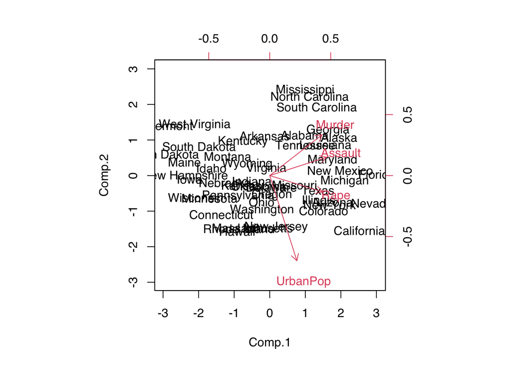

```r
biplot(US_prin,scale = 0)
```

#### 3. 요인분석

요인분석 : 변수들 간의 상관관계를 고려하여 서로 유사한 변수들을 묵어 새로운 잠재요인들을 추출

> factanla(data, factors=n, rotation=‘varimax’, scores=‘regression’,…)
> - factors : 요인의 개수 지정
> - rotation : 요인 회전방법(‘varimax,’promax’,‘none’)
> - scores : 요인점수 계산 방법(‘regression’,‘Bartlett’)

```r
data("swiss")
Min <- apply(swiss,2,min)
Max <- apply(swiss,2,max)
swiss_fa <- scale(swiss, center=Min, scale = (Max-Min))

# i) 고유값을 통해 요인 개수 설정
swiss.prin <- princomp(swiss, cor = TRUE)
swiss.prin$sdev^2
```

```
##    Comp.1    Comp.2    Comp.3    Comp.4    Comp.5    Comp.6
## 3.1997570 1.1883082 0.8476098 0.4389287 0.2045337 0.1208626
```

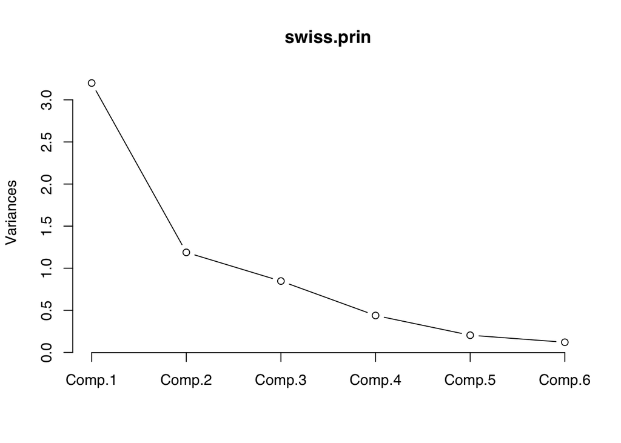

```r
# => 고유값이 1 이상인 개수를 요인 개수로 설정

# ii) screeplot을 통해 요인 개수 설정
plot(swiss.prin,type='l')
```

```r
# => 기울기가 완만해지는 점 전까지를 요인 개수로 설정

# iii) cor(df)를 통해 직접 요인 개수 설정
cor(swiss)
```

```
##                   Fertility Agriculture Examination   Education   Catholic
## Fertility         1.0000000  0.35307918  -0.6458827 -0.66378886  0.4636847
## Agriculture       0.3530792  1.00000000  -0.6865422 -0.63952252  0.4010951
## Examination      -0.6458827 -0.68654221   1.0000000  0.69841530 -0.5727418
## Education        -0.6637889 -0.63952252   0.6984153  1.00000000 -0.1538589
## Catholic          0.4636847  0.40109505  -0.5727418 -0.15385892  1.0000000
## Infant.Mortality  0.4165560 -0.06085861  -0.1140216 -0.09932185  0.1754959
##                  Infant.Mortality
## Fertility              0.41655603
## Agriculture           -0.06085861
## Examination           -0.11402160
## Education             -0.09932185
## Catholic               0.17549591
## Infant.Mortality       1.00000000
```

```r
# => 상관계수 값이 높은 그룹의 개수를 요인 개수로 설정

factanal(swiss_fa, factors=2)
```

```
##
## Call:
## factanal(x = swiss_fa, factors = 2)
##
## Uniquenesses:
##        Fertility      Agriculture      Examination        Education
##            0.420            0.492            0.270            0.005
##         Catholic Infant.Mortality
##            0.061            0.960
##
## Loadings:
##                  Factor1 Factor2
## Fertility        -0.652   0.393
## Agriculture      -0.631   0.333
## Examination       0.685  -0.510
## Education         0.997
## Catholic         -0.124   0.961
## Infant.Mortality          0.175
##
##                Factor1 Factor2
## SS loadings      2.311   1.481
## Proportion Var   0.385   0.247
## Cumulative Var   0.385   0.632
##
## Test of the hypothesis that 2 factors are sufficient.
## The chi square statistic is 20.99 on 4 degrees of freedom.
## The p-value is 0.000318
```

```r
# => Cumulative Var : 전체 데이터 분산의 %를 설명
# => p-value : 기각=요인 분석 개수 적절X
```

#### 4. 표준화와 정규화

- 표준화

> scale(data,center,scale)
- 정규화

> scale(data, center=Min, scale=Max-Min)

```r
data(iris)
Min <- apply(iris[1:4],2,min)
Max <- apply(iris[1:4],2,max)

# 표준화
head(scale(iris[1:4]))
```

```
##      Sepal.Length Sepal.Width Petal.Length Petal.Width
## [1,]   -0.8976739  1.01560199    -1.335752   -1.311052
## [2,]   -1.1392005 -0.13153881    -1.335752   -1.311052
## [3,]   -1.3807271  0.32731751    -1.392399   -1.311052
## [4,]   -1.5014904  0.09788935    -1.279104   -1.311052
## [5,]   -1.0184372  1.24503015    -1.335752   -1.311052
## [6,]   -0.5353840  1.93331463    -1.165809   -1.048667
```

```r
# 정규화
head(scale(iris[1:4],center=Min,scale=Max-Min))
```

```
##      Sepal.Length Sepal.Width Petal.Length Petal.Width
## [1,]   0.22222222   0.6250000   0.06779661  0.04166667
## [2,]   0.16666667   0.4166667   0.06779661  0.04166667
## [3,]   0.11111111   0.5000000   0.05084746  0.04166667
## [4,]   0.08333333   0.4583333   0.08474576  0.04166667
## [5,]   0.19444444   0.6666667   0.06779661  0.04166667
## [6,]   0.30555556   0.7916667   0.11864407  0.12500000
```

### 3. 데이터 결합 및 요약

#### 1. 결합

> rbind()

> cbind()

> merge()

#### 2. 요약

> aggregate()

> table()

> prop.table()

> subset()

#### 3. apply

> apply()

> lapply()

> sapply()

> vapply()

> mapply()

> tapply()

### 4. 패키지 이용

#### 1. reshape2

> **reshape2 패키지**

> melt(df, id.vars, measure.vars) : 열을 행으로
> - id.vars : 기준이 되는 식별자 칼럼들
> - measure.vars : 측정치 칼럼들

> **reshape2 패키지**

> dcast(df, formula, fun.aggregate) : 행을 열로
> - formula : id변수 ~ variable변수
> - fun.aggregate : id변수를 기준으로 여러 행이 존재할 경우 해당 행들에 적용할 집합 함수

```r
library(reshape2)
data("airquality")
dt <- airquality

# melt()
dt_melt <- melt(dt, id.vars = c('Month','Day'), na.rm = T)
head(dt_melt)
```

```
##   Month Day variable value
## 1     5   1    Ozone    41
## 2     5   2    Ozone    36
## 3     5   3    Ozone    12
## 4     5   4    Ozone    18
## 6     5   6    Ozone    28
## 7     5   7    Ozone    23
```

```r
# dcast()
head(dcast(dt_melt, Month+Day~...))
```

```
##   Month Day Ozone Solar.R Wind Temp
## 1     5   1    41     190  7.4   67
## 2     5   2    36     118  8.0   72
## 3     5   3    12     149 12.6   74
## 4     5   4    18     313 11.5   62
## 5     5   5    NA      NA 14.3   56
## 6     5   6    28      NA 14.9   66
```

### 5. 결측치

#### 1. 결측치

- 결측치 확인

> is.na()

> complete.cases()
- 결측치 처리
1. 결측치 제거
2. 중앙값/평균값/최빈값/상수값 대치

   > **DMwR 패키지 (깃허브를 통해)**

   > centralImputation(data) : 중앙값

   > centralValue(data) : 중앙값 / 최빈값
3. K-NN

   > **DMwR 패키지 (깃허브를 통해)**

   > knnImputation(data, k)
4. MICE(Multivariate Imputation by Chained Equation)
5. 딥러닝을 활용한 Imputation

※ 가이드라인  
10% 미만 : 삭제 or 대치  
10% ~ 50% : regression or model based imputation  
50% 이상 : 해당 변수 자체 제거

```r
# DMwR 패키지
remotes::install_github("cran/DMwR")
library(DMwR)
```

#### 2. 이상치

> quantile()

> fivenum()

> summary()

> boxplot()

### 6. 날짜 데이터

> Sys.Date() : 현재 날짜

> Sys.time() : 현재 날짜와 시간

> as.Date()

> as.POSIXct()

> as.POSIXlt()

### 7. 클래스불균형

#### 1. 업 샘플링 / 다운 샘플링

> **caret 패키지**

> upSample(x, y)

> downSample(x, y)

#### 2. SMOTE

> **DMwR 패키지 (깃허브를 통해)**

> SMOTE(form, data, perc.over, k, perc.under)
> - perc.over : 적은 쪽의 데이터를 얼마만큼의 비율로 샘플링을 추가할지
> - k : 고려할 최근접 이웃의 수
> - perc.under : 많은 쪽의 데이터 중 얼마만큼의 비율로 샘플링을 추가할지

⓵ 오버샘플링 수 = perc.over/100 * n(적은 범주의 데이터 수)

⓶ 언더샘플링 수 = perc.under/100 * ⓵

=> 적은 범주의 데이터 수 = n+⓵ / 많은 범주의 데이터 수 = ⓶

```r
remotes::install_github("cran/DMwR")
library(DMwR)

data("iris")
df <- iris[,c(1,2,5)]
df$Species <- factor(ifelse(df$Species=='setosa','rare','common'))
table(df$Species)
```

```
##
## common   rare
##    100     50
```

```r
newData <- SMOTE(Species~., df, perc.over = 600,perc.under = 100)

table(df$Species)
```

```
##
## common   rare
##    100     50
```

```r
table(newData$Species)
```

```
##
## common   rare
##    300    350
```